# Climate Analyses 1

Devin Gamble

5/9/2020

## Objective:

#### Identify the *climate variables*, *periods* (YoC, Norms), and *temporal windows* (seasons, months, before/after) for which phenology is most sensitive.

- See ‘EDA2.Rmd’ for exploration of different models. Currently, it looks as though MAT, MAP, and Tmin/ave + PPT in the spring explain the most variation in DOY.

```
## [1] 1674
```

```
## [1] 1674
```

Moving forward it is probably best to use `nemo_df2` (records after 1900) or `nemo_e0_5` (records with errors 0-5 km).

### Annual Climate Variables

Models are constructed to see which climate variables explain the most variation in DOY, including covariates (elevation, lat OR long [not year]) to control for additional variation, assuming no autocorrelation. Climate data are site [and year; YoC/anomalies] specific - control for elev but not lat/long in analyses?

Model selection options  
- Comparative (manual)  
- Stepwise Regression (for multiple related variables - e.g. Tmin for 4 months)  
- More stringent guidelines  
- include random effect of error distance?

Long Term Climate 100Y

| Observations | 1677 |
| --- | --- |
| Dependent variable | DOY |
| Type | OLS linear regression |

| F(3,1673) | 189.86 |
| --- | --- |
| R² | 0.25 |
| Adj. R² | 0.25 |

|  | Est. | S.E. | t val. | p |
| --- | --- | --- | --- | --- |
| (Intercept) | 46.30 | 56.55 | 0.82 | 0.41 |
| elev_m | 0.03 | 0.00 | 22.92 | 0.00 |
| long | -1.63 | 0.30 | -5.33 | 0.00 |
| year | -0.08 | 0.02 | -4.13 | 0.00 |

Standard errors: OLS

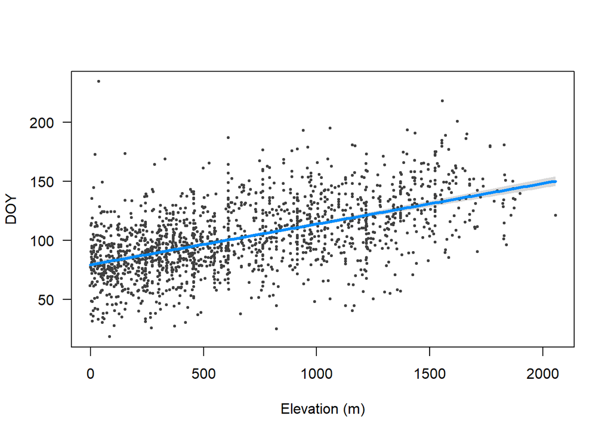

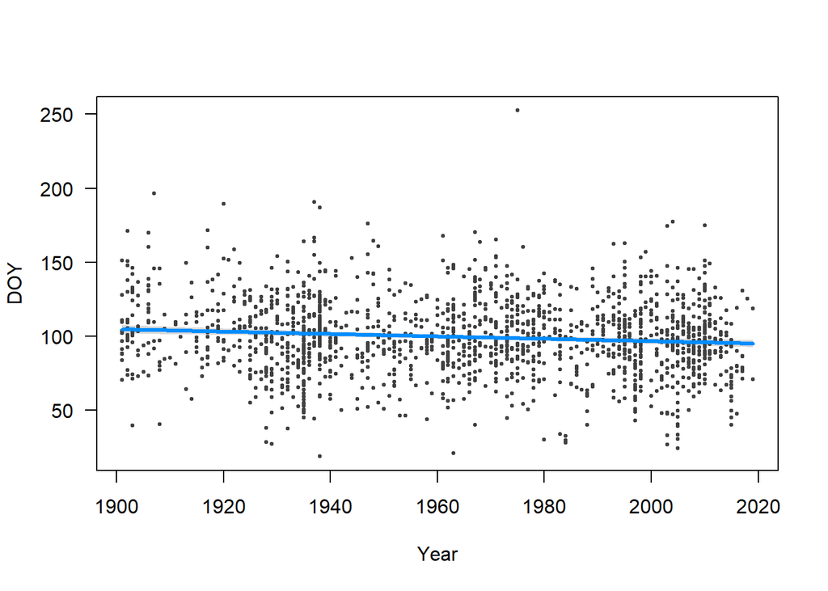

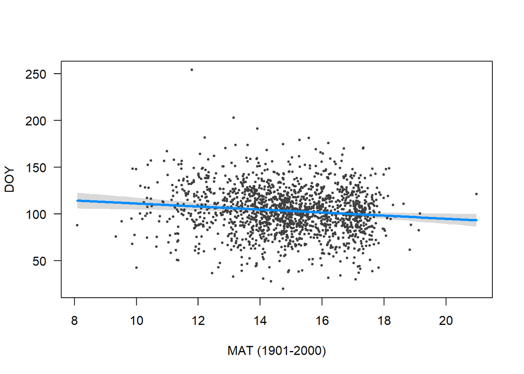

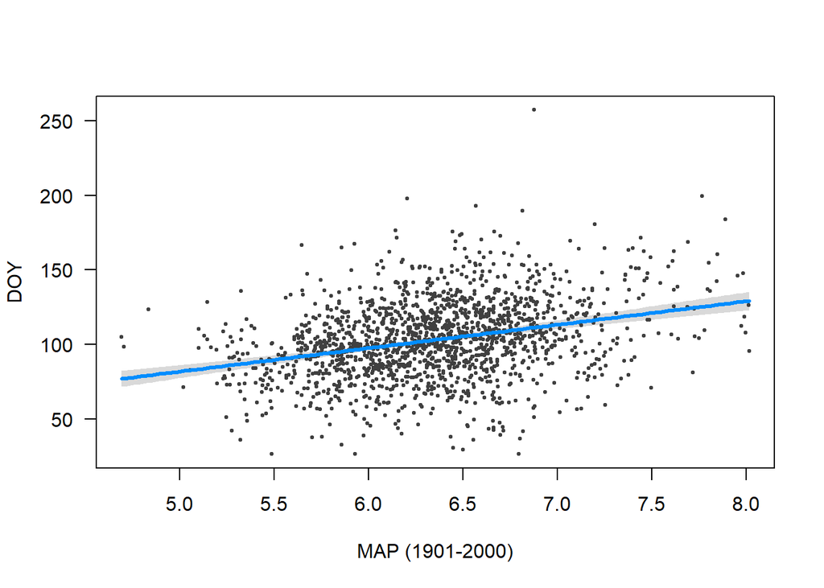

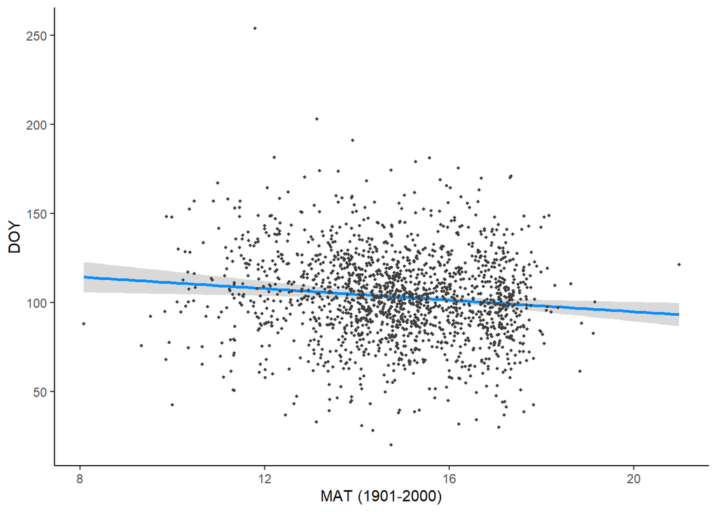

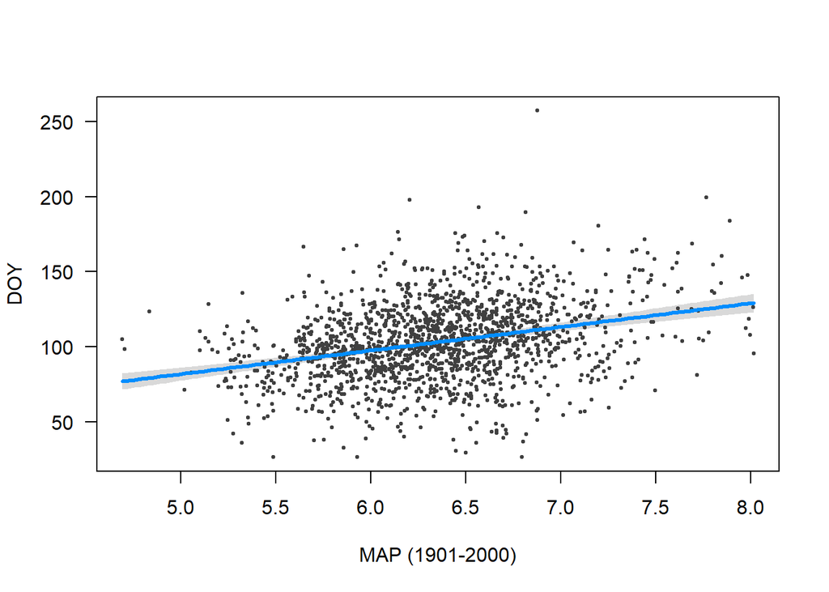

```r
#100Y

ann_clim1 <- lm(DOY ~ MAT_100Y + MAP_100Y, data = nemo_df2)
ann_clim2 <- lm(DOY ~ MAT_100Y + MAP_100Y + elev_m, data = nemo_df2)
ann_clim3 <- lm(DOY ~ MAT_100Y + MAP_100Y + elev_m + long, data = nemo_df2)
ann_clim4 <- lm(DOY ~ MAT_100Y + MAP_100Y + elev_m + long + year, data = nemo_df2)

summary(ann_clim1)
summary(ann_clim2)
summary(ann_clim3)
summary(ann_clim4)
#Controlling for elevation severely reduces the effect of MAT (ns)
#Controlling for elev and long - the effect of temperature returns but is still quite small

summ(ann_clim3, vif = TRUE) #VIF for long, elev, MAP, MAT is high
```

The relationship b/w DOY and MAT weakens as the model is parameterized,while the estimate of MAP strengthens. There was no significant interaction between any covariates. While MAT still appears to advance DOY, controlling for geography seems to explain a good deal of this variation. Examining seasonal climate and anomalies should shed more light on this.  
[Update: PPT sometimes stronger than Temp in effect on DOY]

**Stepwise Regression** Model Selection

Long-term climate [100Y]

```r
library(MASS) #Load this AFTER data cleaning using dplyr - both have select() ftn.
library(rsq)
library(interactions)

##Annual Variables
summary(ann_clim3)
summary(ann_clim4)


summary(stepAIC(ann_clim4, direction = "both"))

#Check multiple annual variables and remove highly correlated ones?
ann_clim5 <- lm(DOY ~ MAT_100Y + MAP_100Y + NFFD_100Y + CMD_100Y + AHM_100Y, data = nemo_df2)
summ(stepAIC(ann_clim5, direction = "both"),scale = TRUE)
```

Everything at the annual scale for 100Y averages is strongly correlated (see EDA2.Rmd). Refer to `ann_clim3` model above (controls for elev_m and long).

For Seasonal variables, stepwise regression with: - Tmin & Tave (Winter, spring, summer) [No Tmax]  
- PPT (Winter, Spring, Summer)

May also consider  
- DD > 5 (spring and winter)  
- DD > 18 (spring and summer)?  
- NFFD (winter, spring) x elev? with PAS?  
- CMD (winter, spring, summer)? RH?

From ‘EDA2.Rmd’, Both Spring temperature and precipitation (from 100Y averages) appeared to be the most influential on DOY. Tave had a higher R2 and Beta than Tmin for spring temps…

100Y- separate models by seasons,

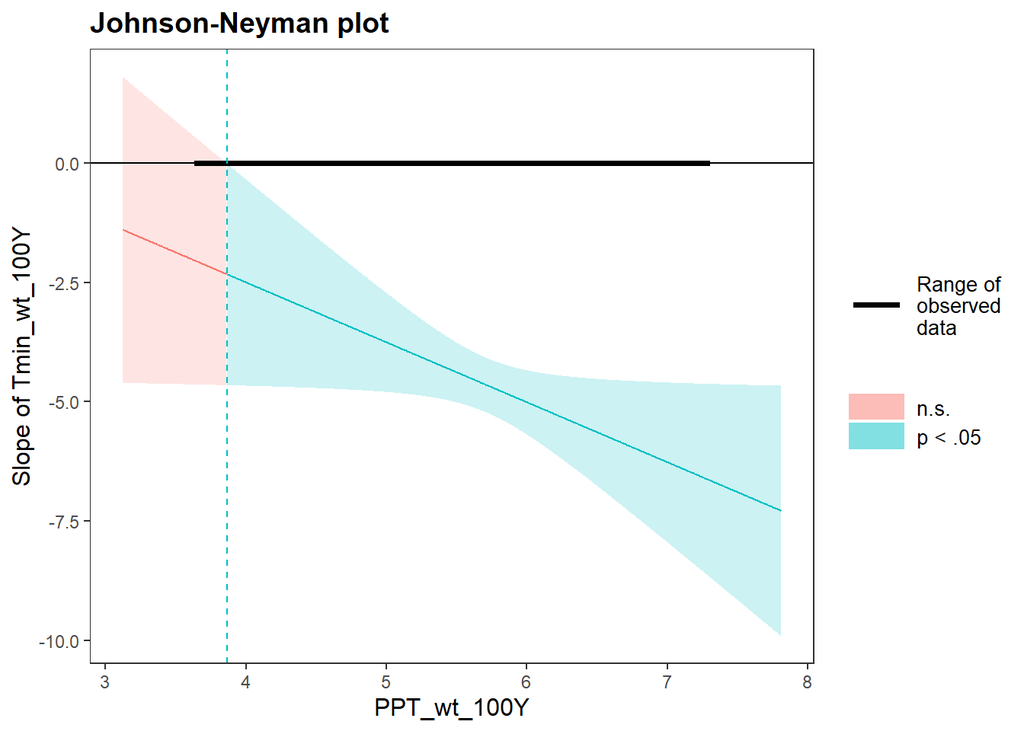

```r
####Seasonal variables
#Winter Conditions
sz_clim1 <- lm(DOY ~ Tmin_wt_100Y + Tave_wt_100Y, data = nemo_df2)
summary(sz_clim1)
sz_clim1.1 <- lm(DOY ~ Tmin_wt_100Y + Tave_wt_100Y + PPT_wt_100Y, data = nemo_df2)
summary(sz_clim1.1) #These have low R2 and high SE, plus estimates are crazy

sz_clim1.2 <- lm(DOY ~ Tmin_wt_100Y + PPT_wt_100Y + PPT_wt_100Y*Tmin_wt_100Y, data = nemo_df2)
summary(sz_clim1.2) #R2 - 0.18, interaction B = -1.25     #Tmin more significant, remove Tave?
#Interaction more significant wyhen Tave retained
summary(stepAIC(sz_clim1.2, direction = "both"))

johnson_neyman(sz_clim1.2, pred = "Tmin_wt_100Y", modx = "PPT_wt_100Y")
```

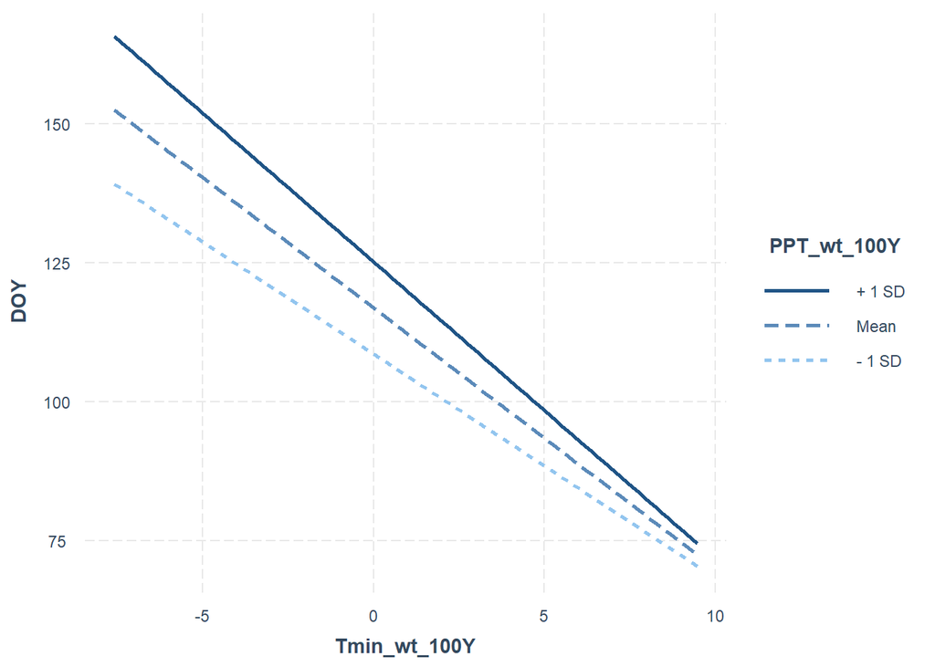

```r
interact_plot(sz_clim1.2, pred = "Tmin_wt_100Y", modx = "PPT_wt_100Y")
```

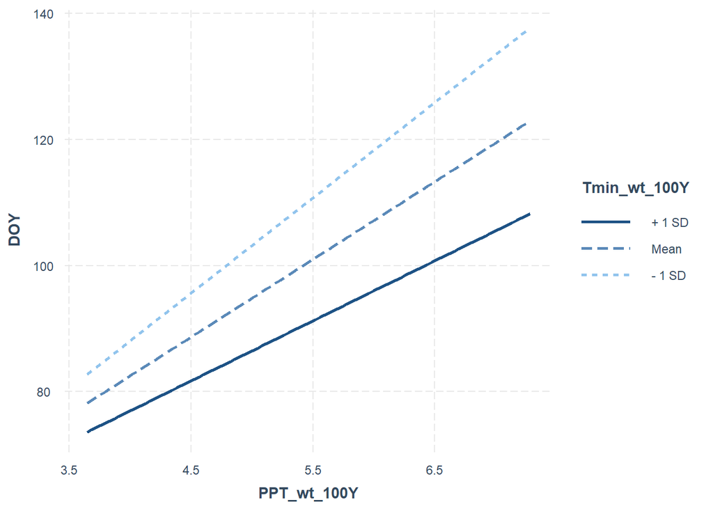

```r
interact_plot(sz_clim1.2, pred = "PPT_wt_100Y", modx = "Tmin_wt_100Y")
```

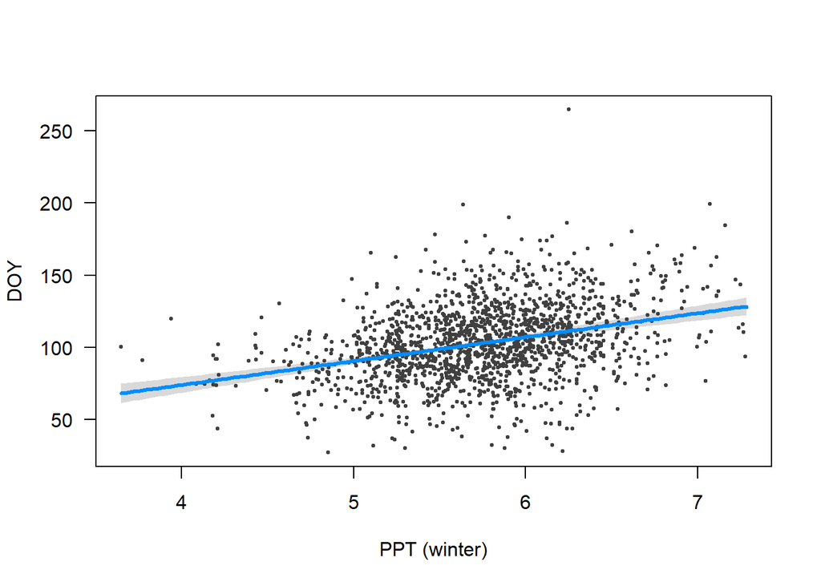

```r
#Building a "standard" model

sz_wt_lm <- lm(DOY ~ Tmin_wt_100Y + PPT_wt_100Y + Tmin_wt_100Y*PPT_wt_100Y + elev_m + long + year, data = nemo_df2)
summary(sz_wt_lm)
#NS Interaction Removed according to stepwise regression
summary(stepAIC(sz_wt_lm, direction = "both"))

visreg(sz_wt_lm, xvar = "PPT_wt_100Y", xlab = "PPT (winter)", points = list(col = "#404040"))
```

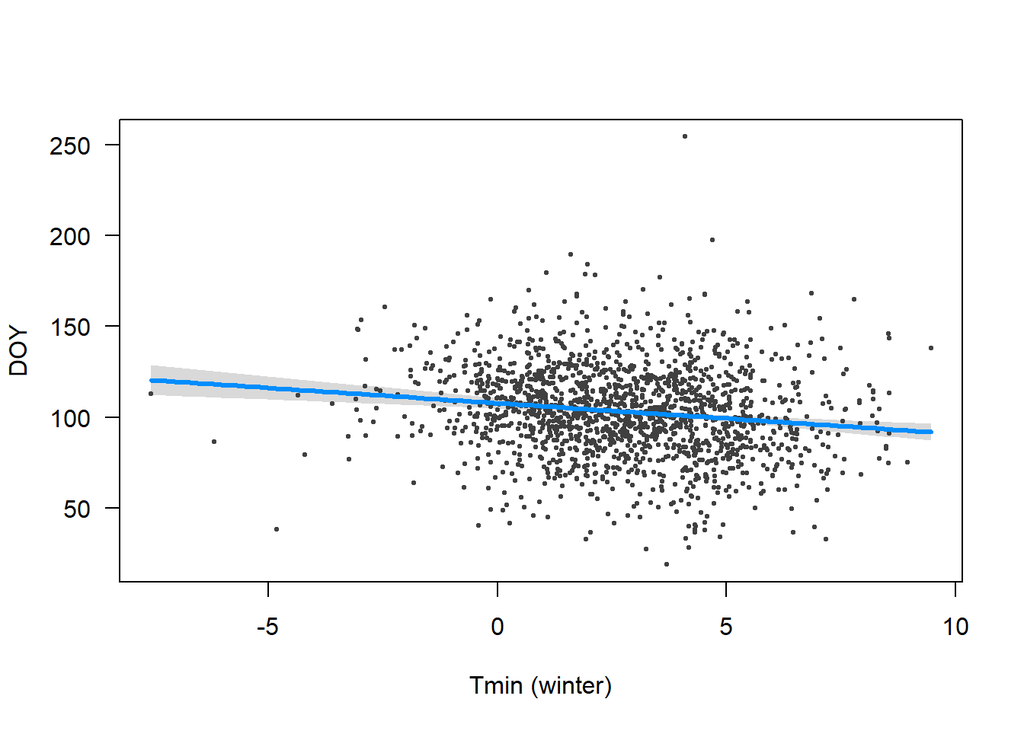

```r
visreg(sz_wt_lm, xvar = "Tmin_wt_100Y", xlab = "Tmin (winter)", points = list(col = "#404040"))
```

Controlling for geographic location (long and elev), the interaction between Tmin_wt and PPT_wt disappears!  
Independently, PPT_wt still has a large, significant delaying effect and Tmin_wt has an advancing effect.  
Including year as a covariate slightly improves $R^2$ and Tmin estimate.  
Long slightly more significant than Lat…

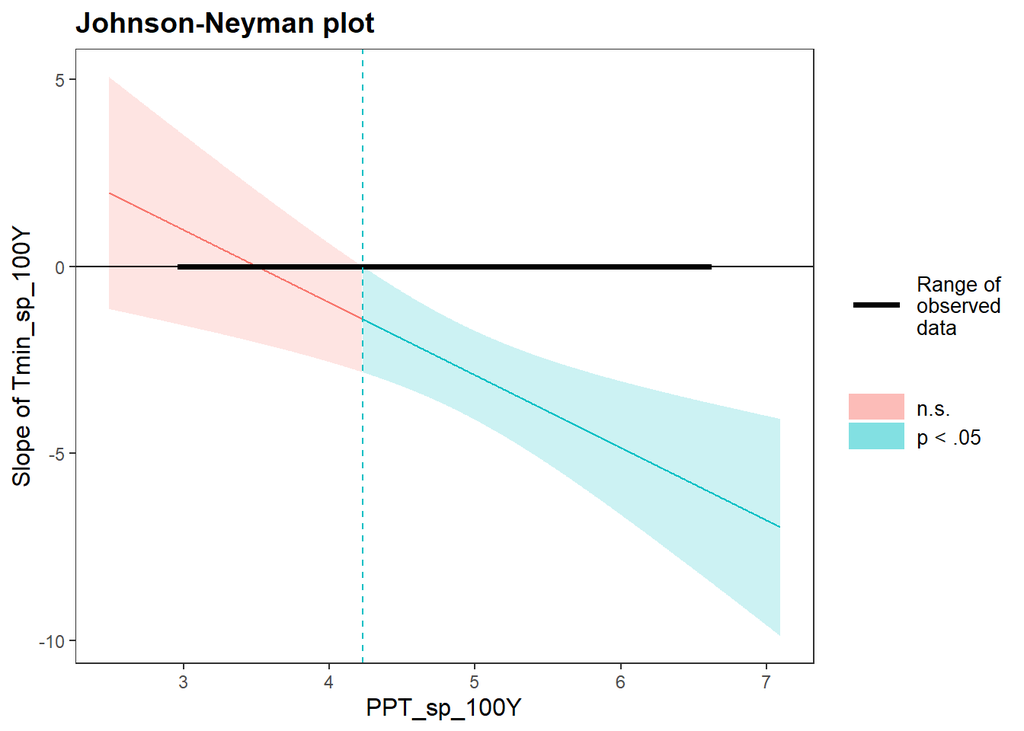

```r
#Spring Conditions
sz_clim2 <- lm(DOY ~ Tmin_sp_100Y + Tave_sp_100Y, data = nemo_df2)
summary(sz_clim2)
sz_clim2.1 <- lm(DOY ~ Tmin_sp_100Y + Tave_sp_100Y +  PPT_sp_100Y, data = nemo_df2)
summary(sz_clim2.1)

sz_clim2.2 <- lm(DOY ~ Tmin_sp_100Y + Tave_sp_100Y + PPT_sp_100Y + Tmin_sp_100Y*PPT_sp_100Y, data = nemo_df2)
summary(sz_clim2.2) #Interaction with Tmin much more significant, higher R2 and estimate
#Tave does still explain some variation, despite the interaction. Removed
summary(stepAIC(sz_clim2.2, direction = "both")) #All retained


johnson_neyman(sz_clim2.2, pred = "Tmin_sp_100Y", modx = "PPT_sp_100Y")
```

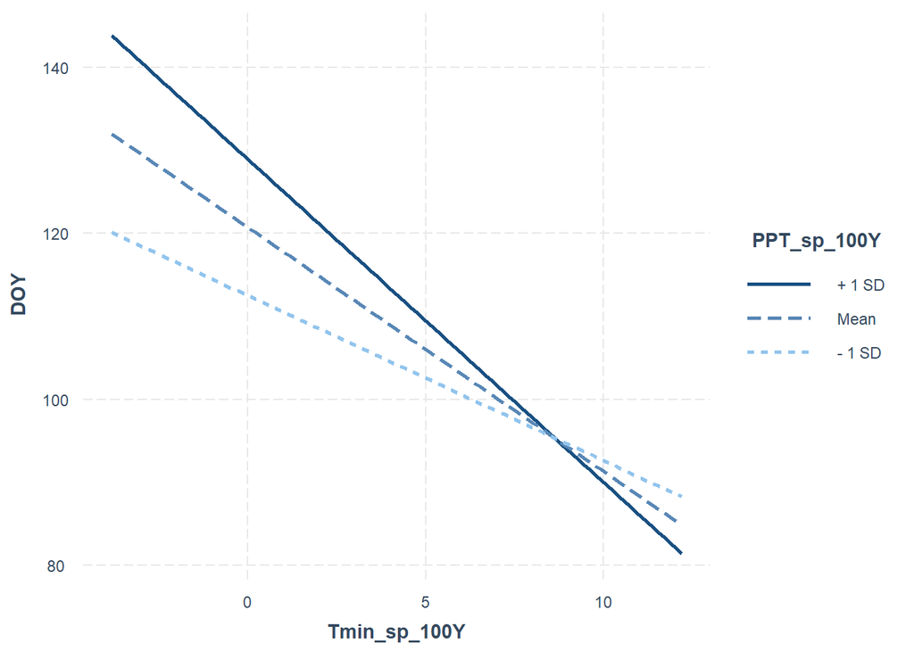

```r
interact_plot(sz_clim2.2, pred = "Tmin_sp_100Y", modx = "PPT_sp_100Y")
```

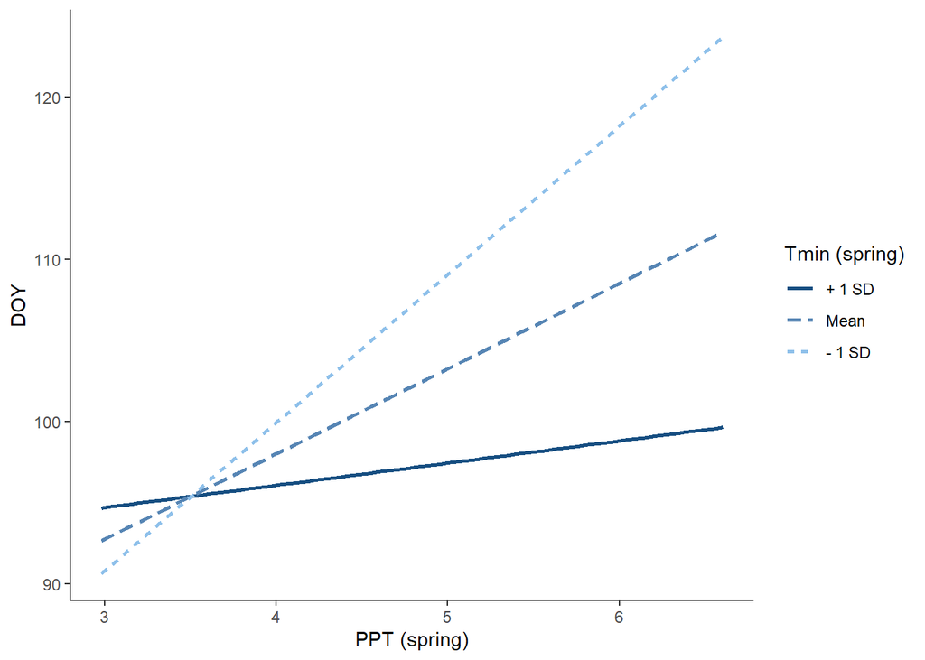

```r
interact_plot(sz_clim2.2, pred = "PPT_sp_100Y", modx = "Tmin_sp_100Y", x.label = "PPT (spring)", legend.main = "Tmin (spring)") + theme_classic()
```

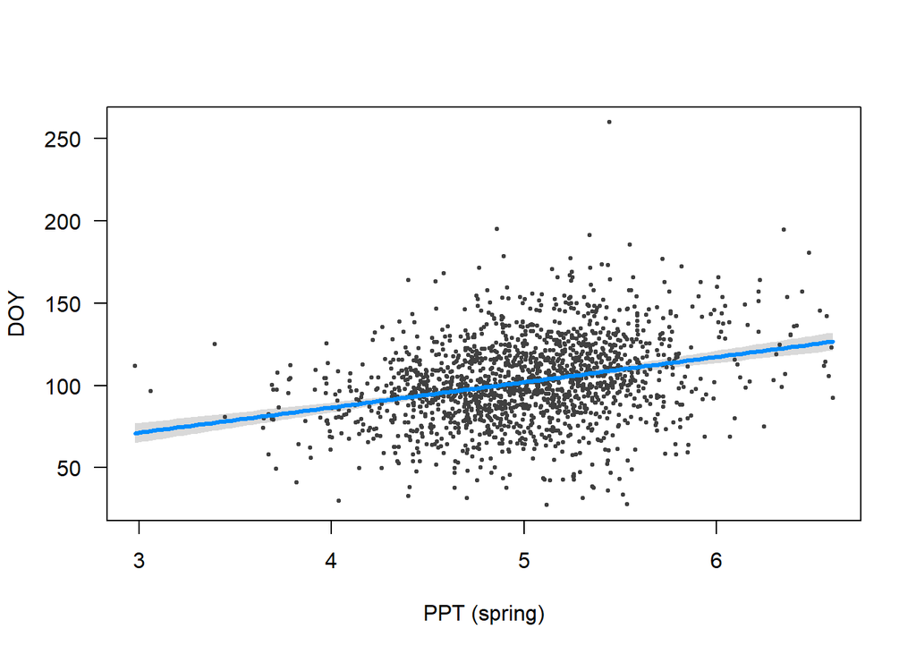

```r
#Swapping Tave for DD>5: similar but much weaker. DD v correlated to Tave

#Building a "standard" model

sz_sp_lm <- lm(DOY ~ Tmin_sp_100Y + PPT_sp_100Y + Tmin_sp_100Y*PPT_sp_100Y + elev_m + long + year, data = nemo_df2)
summary(sz_sp_lm) #interaction becomes ns...
summary(stepAIC(sz_sp_lm, direction = "both"))


#Removing Interaction term...
sz_sp_lm2 <- lm(DOY ~ Tmin_sp_100Y + PPT_sp_100Y + elev_m + long + year, data = nemo_df2)
summary(stepAIC(sz_sp_lm2, direction = "both"))

#Compare with model using Tave instead of Tmin
sz_sp_lm3 <- lm(DOY ~ Tave_sp_100Y + PPT_sp_100Y + elev_m + long + year, data = nemo_df2)
AIC(sz_sp_lm2, sz_sp_lm3) #

visreg(sz_sp_lm2, xvar = "PPT_sp_100Y", xlab = "PPT (spring)", points = list(col = "#404040"))
```

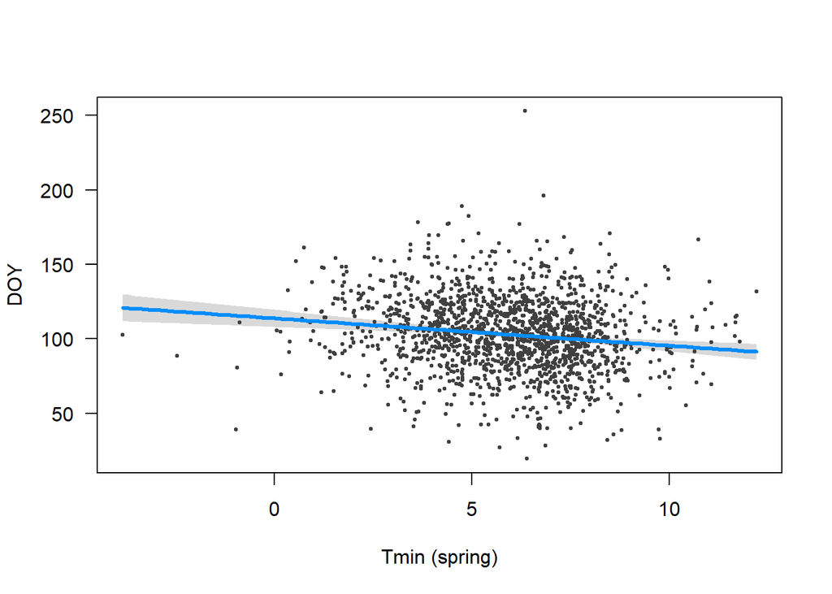

```r
visreg(sz_sp_lm2, xvar = "Tmin_sp_100Y", xlab = "Tmin (spring)", points = list(col = "#404040"))
```

Interaction term becomes marginally significant. Removing it, we see results similar to the above winter ‘standard’ model - advancing effect of Tmin (+ year), delaying effect of PPT (+ long, elevation)

Tmin appears to explain more variation than Tave *in its interaction with PPT_sp*. Interaction is stronger with Tmin than Tave and PPT. Better $R^2$ and AIC with Tmin model (no interaction).

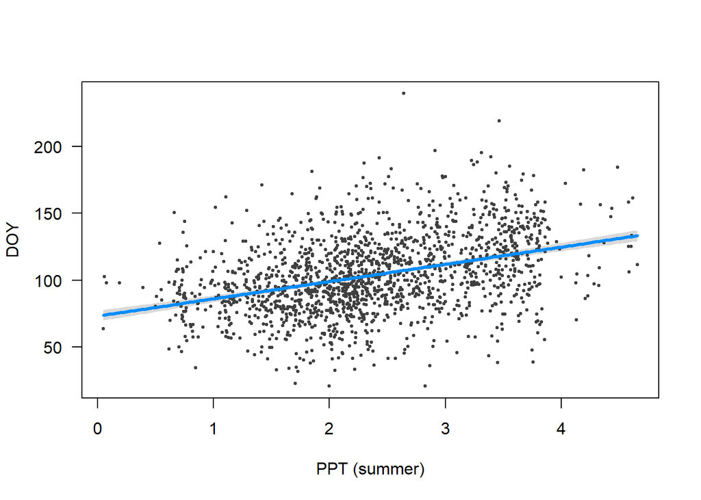

```r
#Summer Conditions
sz_clim3 <- lm(DOY ~ Tmin_sm_100Y + Tave_sm_100Y, data = nemo_df2)
summary(sz_clim3)
sz_clim3.1 <- lm(DOY ~ Tmin_sm_100Y + PPT_sm_100Y, data = nemo_df2)
summary(sz_clim3.1)

sz_clim3.2 <- lm(DOY ~ Tmin_sm_100Y +  PPT_sm_100Y + Tmin_sm_100Y*PPT_sm_100Y, data = nemo_df2)
summary(stepAIC(sz_clim3.2, direction = "both"))
#Looks like Summer PPT has the largest effect, with Tmin marginally advancing DOY. No interaction
visreg(sz_clim3.2, xvar = "PPT_sm_100Y", xlab = "PPT (summer)", points = list(col = "#404040"))
```

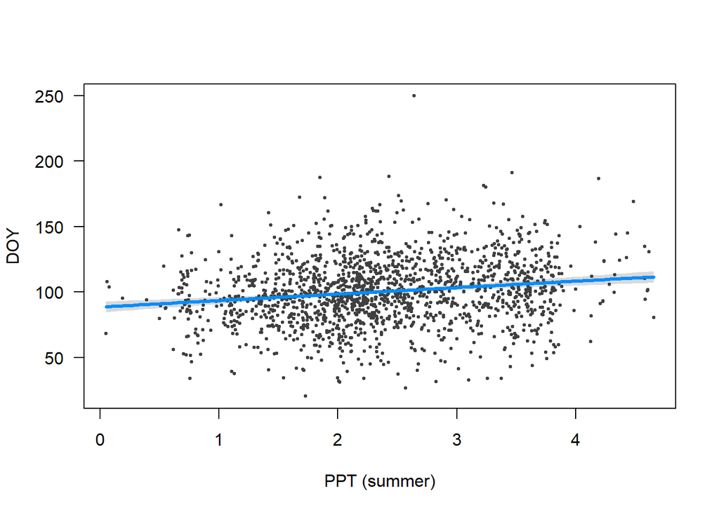

```r
#Building a "standard" model

sz_sm_lm <- lm(DOY ~ Tmin_sm_100Y + PPT_sm_100Y + elev_m + long + year, data = nemo_df2)
summary(sz_sm_lm)
summary(stepAIC(sz_sm_lm, direction = "both"))

visreg(sz_sm_lm, xvar = "PPT_sm_100Y", xlab = "PPT (summer)", points = list(col = "#404040"))
```

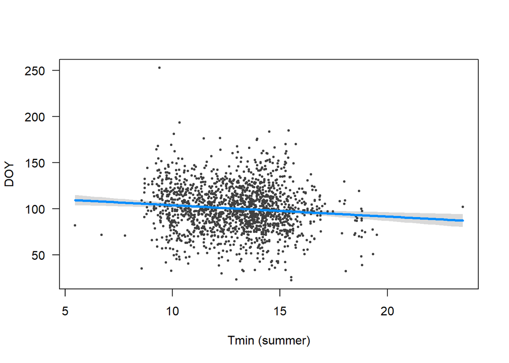

```r
visreg(sz_sm_lm, xvar = "Tmin_sm_100Y", xlab = "Tmin (summer)", points = list(col = "#404040"))
```

Similar trends as in spring and winter models, though parameter estimates are much weaker and there was not even a marginally significant interaction accounting for non-climatic factors.

Tmin consistently appears to have a higher estimate, explain more variation in DOY, and be more significant in models compared to Tave.

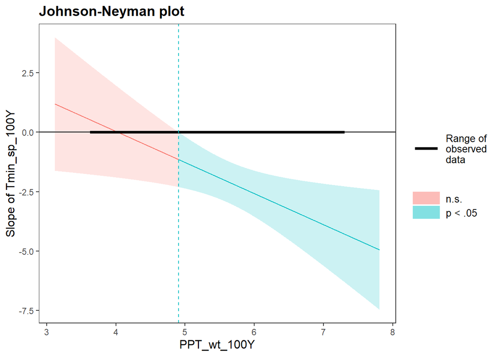

```r
#Combinations of seasonal variables

#main effects
sz_all_lm1 <- lm(DOY ~ Tmin_wt_100Y + Tmin_sp_100Y + Tmin_sm_100Y + PPT_wt_100Y + PPT_sp_100Y + PPT_sm_100Y, data = nemo_df2)
summary(stepAIC(sz_all_lm1,direction = "both"))
#Tmin_sp and PPT_sp stand out

#interactions -spring and winter
sz_all_lm2 <- lm(DOY ~ Tmin_wt_100Y + Tmin_sp_100Y  + PPT_wt_100Y + PPT_sp_100Y, data = nemo_df2)
summary(stepAIC(sz_all_lm2, direction = "both", scope = list(upper = ~Tmin_sp_100Y*Tmin_wt_100Y*PPT_wt_100Y*PPT_sp_100Y, lower = ~1)))
#Shows interaction b/w Tmin_sp *PPT_sp
#But also potential interaction b/w Tmin_sp and PPT_wt



sz_all_lm2.1 <- lm(DOY ~ Tmin_sp_100Y + PPT_wt_100Y + Tmin_sp_100Y*PPT_wt_100Y, data = nemo_df2)
summary(sz_all_lm2.1)

#johnson_neyman(sz_all_lm2.1, pred = "Tmin_sp_100Y", modx = "PPT_wt_100Y")
#interact_plot(sz_all_lm2.1, pred = "Tmin_sp_100Y", modx = "PPT_wt_100Y")
#interact_plot(sz_all_lm2.1, pred = "PPT_wt_100Y", modx = "Tmin_sp_100Y")


sz_all_lm2.2 <- lm(DOY ~ Tmin_sp_100Y + PPT_wt_100Y + Tmin_sp_100Y*PPT_wt_100Y + long + elev_m + year, data = nemo_df2)
summary(stepAIC(sz_all_lm2.2, direction = "both"))
#Unlike before, this interaction persists when controlling for geographic range and year
#Parameter estimate much weaker, but still significant

#Controlling for geography, though, affects modulating effect in the interaction
johnson_neyman(sz_all_lm2.2, pred = "Tmin_sp_100Y", modx = "PPT_wt_100Y")
```

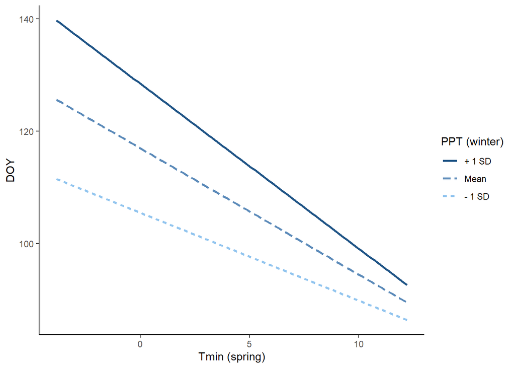

```r
interact_plot(sz_all_lm2.2, pred = "Tmin_sp_100Y", modx = "PPT_wt_100Y", x.label = "Tmin (spring)", legend.main = "PPT (winter)") + theme_classic()
```

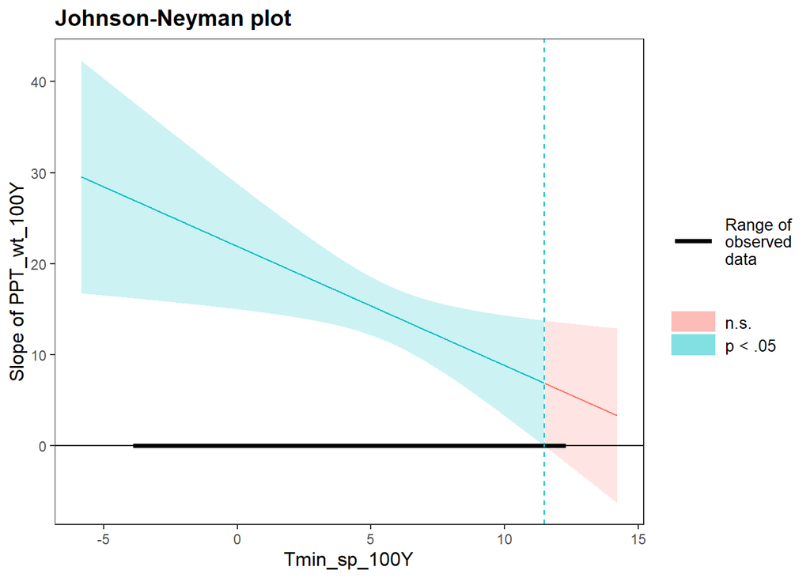

```r
johnson_neyman(sz_all_lm2.2, pred = "PPT_wt_100Y", modx = "Tmin_sp_100Y")
```

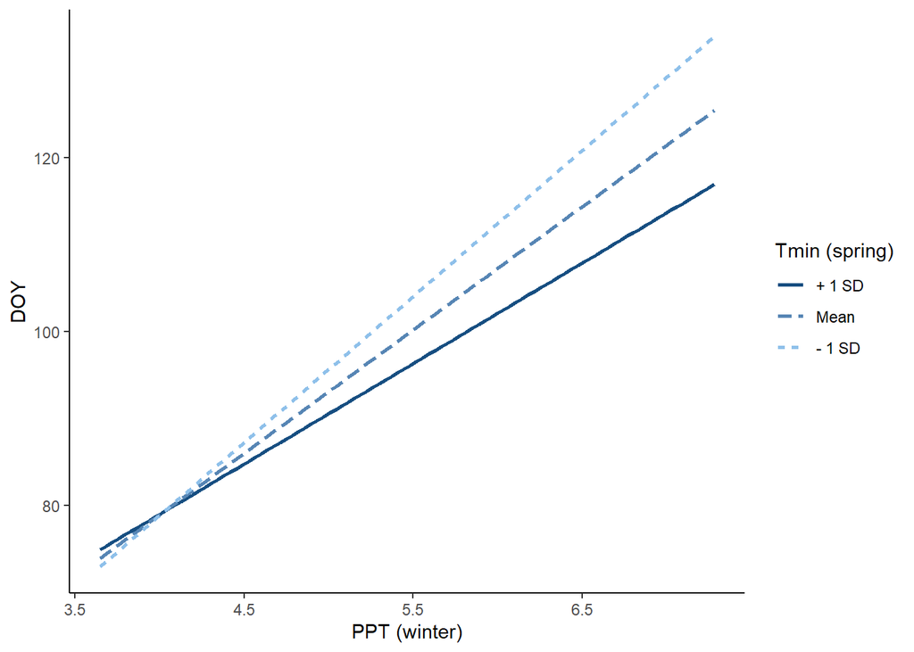

```r
interact_plot(sz_all_lm2.2, pred = "PPT_wt_100Y", modx = "Tmin_sp_100Y", x.label = "PPT (winter)", legend.main = "Tmin (spring)") + theme_classic()
```

```
##
## Call:
## lm(formula = DOY ~ Tmin_wt_100Y + PPT_wt_100Y + elev_m + long +
##     year, data = nemo_df2)
##
## Residuals:
##     Min      1Q  Median      3Q     Max
## -83.006 -14.892  -0.621  14.906 153.197
##
## Coefficients:
##                Estimate Std. Error t value Pr(>|t|)
## (Intercept)  359.097898  62.937628   5.706 1.37e-08 ***
## Tmin_wt_100Y  -1.689955   0.374198  -4.516 6.74e-06 ***
## PPT_wt_100Y   17.089181   1.622966  10.530  < 2e-16 ***
## elev_m         0.021161   0.002175   9.729  < 2e-16 ***
## long           1.743720   0.432253   4.034 5.73e-05 ***
## year          -0.078835   0.019091  -4.129 3.82e-05 ***
## ---
## Signif. codes:  0 '***' 0.001 '**' 0.01 '*' 0.05 '.' 0.1 ' ' 1
##
## Residual standard error: 24.53 on 1671 degrees of freedom
## Multiple R-squared:  0.3019, Adjusted R-squared:  0.2998
## F-statistic: 144.5 on 5 and 1671 DF,  p-value: < 2.2e-16
```

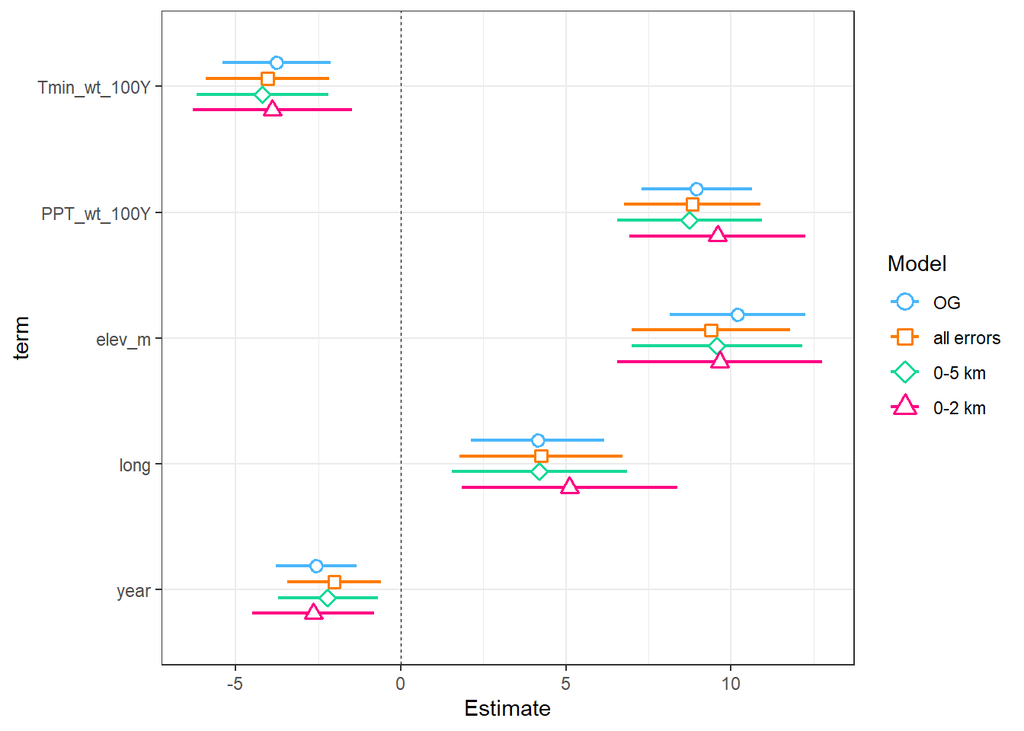

```
##
## Call:
## lm(formula = DOY ~ Tmin_sp_100Y + PPT_sp_100Y + elev_m + long +
##     year, data = nemo_df2)
##
## Residuals:
##     Min      1Q  Median      3Q     Max
## -82.539 -14.937  -0.524  15.097 150.818
##
## Coefficients:
##                Estimate Std. Error t value Pr(>|t|)
## (Intercept)  308.901885  60.762604   5.084 4.12e-07 ***
## Tmin_sp_100Y  -1.842038   0.446211  -4.128 3.84e-05 ***
## PPT_sp_100Y   15.322104   1.569475   9.763  < 2e-16 ***
## elev_m         0.020415   0.002172   9.401  < 2e-16 ***
## long           1.142965   0.382048   2.992  0.00282 **
## year          -0.075461   0.019047  -3.962 7.75e-05 ***
## ---
## Signif. codes:  0 '***' 0.001 '**' 0.01 '*' 0.05 '.' 0.1 ' ' 1
##
## Residual standard error: 24.44 on 1671 degrees of freedom
## Multiple R-squared:  0.3075, Adjusted R-squared:  0.3054
## F-statistic: 148.4 on 5 and 1671 DF,  p-value: < 2.2e-16
```

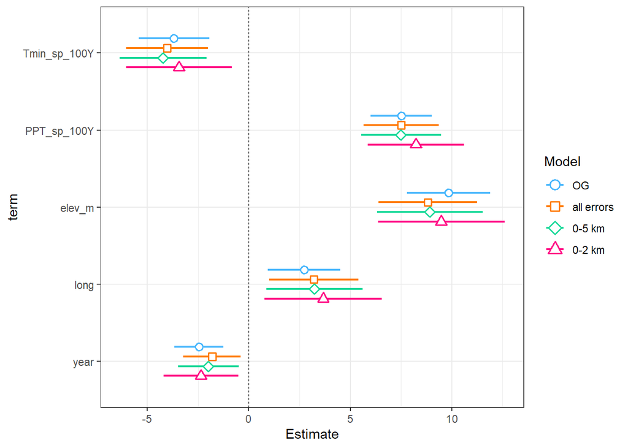

```
##
## Call:
## lm(formula = DOY ~ Tmin_sm_100Y + PPT_sm_100Y + elev_m + long +
##     year, data = nemo_df2)
##
## Residuals:
##     Min      1Q  Median      3Q     Max
## -76.657 -15.486  -0.648  14.847 148.170
##
## Coefficients:
##                Estimate Std. Error t value Pr(>|t|)
## (Intercept)  174.020021  60.701621   2.867 0.004198 **
## Tmin_sm_100Y  -1.228800   0.344874  -3.563 0.000377 ***
## PPT_sm_100Y    4.939042   0.886224   5.573 2.91e-08 ***
## elev_m         0.027873   0.001756  15.875  < 2e-16 ***
## long          -0.677868   0.340596  -1.990 0.046728 *
## year          -0.084236   0.019313  -4.362 1.37e-05 ***
## ---
## Signif. codes:  0 '***' 0.001 '**' 0.01 '*' 0.05 '.' 0.1 ' ' 1
##
## Residual standard error: 24.94 on 1670 degrees of freedom
##   (1 observation deleted due to missingness)
## Multiple R-squared:  0.2784, Adjusted R-squared:  0.2763
## F-statistic: 128.9 on 5 and 1670 DF,  p-value: < 2.2e-16
```

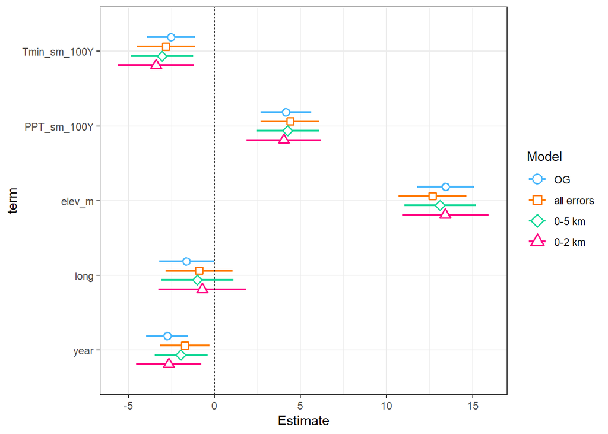

```
##
## Call:
## lm(formula = DOY ~ Tmin_sp_100Y + PPT_wt_100Y + Tmin_sp_100Y *
##     PPT_wt_100Y + elev_m + long + year, data = nemo_df2)
##
## Residuals:
##     Min      1Q  Median      3Q     Max
## -80.908 -14.998  -0.376  14.879 152.825
##
## Coefficients:
##                            Estimate Std. Error t value Pr(>|t|)
## (Intercept)              317.529950  64.949297   4.889 1.11e-06 ***
## Tmin_sp_100Y               5.264354   3.097663   1.699 0.089419 .
## PPT_wt_100Y               21.897077   3.517735   6.225 6.09e-10 ***
## elev_m                     0.020459   0.002181   9.382  < 2e-16 ***
## long                       1.562836   0.416030   3.757 0.000178 ***
## year                      -0.078247   0.019072  -4.103 4.28e-05 ***
## Tmin_sp_100Y:PPT_wt_100Y  -1.308369   0.546166  -2.396 0.016705 *
## ---
## Signif. codes:  0 '***' 0.001 '**' 0.01 '*' 0.05 '.' 0.1 ' ' 1
##
## Residual standard error: 24.49 on 1670 degrees of freedom
## Multiple R-squared:  0.3048, Adjusted R-squared:  0.3023
## F-statistic: 122.1 on 6 and 1670 DF,  p-value: < 2.2e-16
```

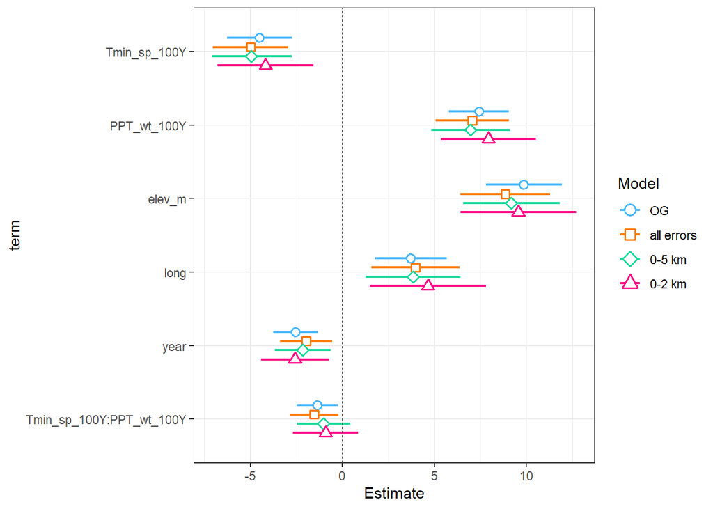

```r
#
#
#


#Spring and summer interactions?
sz_all_lm3 <- lm(DOY ~ Tmin_sm_100Y + Tmin_sp_100Y  + PPT_sm_100Y + PPT_sp_100Y, data = nemo_df2)
summary(stepAIC(sz_all_lm3, direction = "both", scope = list(upper = ~Tmin_sp_100Y*Tmin_sm_100Y*PPT_sm_100Y*PPT_sp_100Y, lower = ~1)))
#Potentially summer Tmin and PPT -- no idea how I found this out of that mess of a model...

sz_all_lm3.1 <- lm(DOY ~ Tmin_sp_100Y + PPT_sm_100Y + Tmin_sp_100Y*PPT_sm_100Y, data = nemo_df2)
summary(sz_all_lm3.1) #still holds
#johnson_neyman(sz_all_lm3.1, pred = "Tmin_sp_100Y", modx = "PPT_sm_100Y")
#interact_plot(sz_all_lm3.1, pred = "Tmin_sp_100Y", modx = "PPT_sm_100Y")
#interact_plot(sz_all_lm3.1, pred = "PPT_sm_100Y", modx = "Tmin_sp_100Y")
sz_all_lm3.2 <- lm(DOY ~ Tmin_sp_100Y + PPT_sm_100Y + Tmin_sp_100Y*PPT_sm_100Y + long + elev_m + year, data = nemo_df2)
summary(stepAIC(sz_all_lm3.2, direction = "both"))
#Only marginally significant when controlling for geography...




#Approach in Matthews & Mazer

sz_clim5 <- lm(DOY ~ Tmin_sp_100Y + Tave_sp_100Y + PPT_sp_100Y, data = nemo_df2)
summary(sz_clim5)


sz_clim6 <- lm(DOY ~ Tmin_sp_100Y + Tave_sp_100Y + PPT_sp_100Y + Tmin_sp_100Y*Tave_sp_100Y*PPT_sp_100Y, data = nemo_df2)
summary(sz_clim6)
```

Year of Collection Models [or Anomaly Models]